# Optimal Treatment Analysis

## Outcome Variable

**Outcome Variable:** haz

## Predictor Variables

**Intervention Variable:** rain_quartile

**Adjustment Set:**

unadjusted

## Stratifying Variables

The analysis was stratified on these variable(s):

- studyid
- country
- agecat

## Data Summary

| studyid | country | agecat | rain_quartile | n_cell | n |
| --- | --- | --- | --- | --- | --- |
| CMC-V-BCS-2002 | India | Birth | 1 | 18 | 92 |
| CMC-V-BCS-2002 | India | Birth | 2 | 25 | 92 |
| CMC-V-BCS-2002 | India | Birth | 3 | 30 | 92 |
| CMC-V-BCS-2002 | India | Birth | 4 | 19 | 92 |
| CMC-V-BCS-2002 | India | 6 months | 1 | 101 | 369 |
| CMC-V-BCS-2002 | India | 6 months | 2 | 111 | 369 |
| CMC-V-BCS-2002 | India | 6 months | 3 | 97 | 369 |
| CMC-V-BCS-2002 | India | 6 months | 4 | 60 | 369 |
| CMC-V-BCS-2002 | India | 24 months | 1 | 87 | 333 |
| CMC-V-BCS-2002 | India | 24 months | 2 | 90 | 333 |
| CMC-V-BCS-2002 | India | 24 months | 3 | 94 | 333 |
| CMC-V-BCS-2002 | India | 24 months | 4 | 62 | 333 |
| CMIN | Bangladesh | Birth | 1 | 7 | 26 |
| CMIN | Bangladesh | Birth | 2 | 6 | 26 |
| CMIN | Bangladesh | Birth | 3 | 6 | 26 |
| CMIN | Bangladesh | Birth | 4 | 7 | 26 |
| CMIN | Bangladesh | 6 months | 1 | 50 | 243 |
| CMIN | Bangladesh | 6 months | 2 | 62 | 243 |
| CMIN | Bangladesh | 6 months | 3 | 71 | 243 |
| CMIN | Bangladesh | 6 months | 4 | 60 | 243 |
| CMIN | Bangladesh | 24 months | 1 | 72 | 224 |
| CMIN | Bangladesh | 24 months | 2 | 64 | 224 |
| CMIN | Bangladesh | 24 months | 3 | 52 | 224 |
| CMIN | Bangladesh | 24 months | 4 | 36 | 224 |
| CONTENT | Peru | Birth | 1 | 0 | 2 |
| CONTENT | Peru | Birth | 2 | 2 | 2 |
| CONTENT | Peru | Birth | 3 | 0 | 2 |
| CONTENT | Peru | Birth | 4 | 0 | 2 |
| CONTENT | Peru | 6 months | 1 | 62 | 215 |
| CONTENT | Peru | 6 months | 2 | 32 | 215 |

[output cut: 238 more lines]

The following strata were considered:

- studyid: CMC-V-BCS-2002, country: India, agecat: 24 months
- studyid: CMC-V-BCS-2002, country: India, agecat: 6 months
- studyid: CMC-V-BCS-2002, country: India, agecat: Birth
- studyid: CMIN, country: Bangladesh, agecat: 24 months
- studyid: CMIN, country: Bangladesh, agecat: 6 months
- studyid: CMIN, country: Bangladesh, agecat: Birth
- studyid: CONTENT, country: Peru, agecat: 24 months
- studyid: CONTENT, country: Peru, agecat: 6 months
- studyid: CONTENT, country: Peru, agecat: Birth
- studyid: EE, country: Pakistan, agecat: 24 months
- studyid: EE, country: Pakistan, agecat: 6 months
- studyid: EE, country: Pakistan, agecat: Birth
- studyid: GMS-Nepal, country: Nepal, agecat: 24 months
- studyid: GMS-Nepal, country: Nepal, agecat: 6 months
- studyid: GMS-Nepal, country: Nepal, agecat: Birth
- studyid: Guatemala BSC, country: Guatemala, agecat: 6 months
- studyid: IRC, country: India, agecat: 24 months
- studyid: IRC, country: India, agecat: 6 months
- studyid: IRC, country: India, agecat: Birth
- studyid: JiVitA-3, country: Bangladesh, agecat: 24 months
- studyid: JiVitA-3, country: Bangladesh, agecat: 6 months
- studyid: JiVitA-3, country: Bangladesh, agecat: Birth
- studyid: JiVitA-4, country: Bangladesh, agecat: 24 months
- studyid: JiVitA-4, country: Bangladesh, agecat: 6 months
- studyid: JiVitA-4, country: Bangladesh, agecat: Birth
- studyid: Keneba, country: Gambia, agecat: 24 months
- studyid: Keneba, country: Gambia, agecat: 6 months
- studyid: Keneba, country: Gambia, agecat: Birth
- studyid: LCNI-5, country: Malawi, agecat: 24 months
- studyid: LCNI-5, country: Malawi, agecat: 6 months
- studyid: MAL-ED, country: Bangladesh, agecat: 24 months
- studyid: MAL-ED, country: Bangladesh, agecat: 6 months
- studyid: MAL-ED, country: Bangladesh, agecat: Birth
- studyid: MAL-ED, country: Brazil, agecat: 24 months
- studyid: MAL-ED, country: Brazil, agecat: 6 months
- studyid: MAL-ED, country: Brazil, agecat: Birth
- studyid: MAL-ED, country: India, agecat: 24 months
- studyid: MAL-ED, country: India, agecat: 6 months
- studyid: MAL-ED, country: India, agecat: Birth
- studyid: MAL-ED, country: Nepal, agecat: 24 months
- studyid: MAL-ED, country: Nepal, agecat: 6 months
- studyid: MAL-ED, country: Nepal, agecat: Birth
- studyid: MAL-ED, country: Peru, agecat: 24 months
- studyid: MAL-ED, country: Peru, agecat: 6 months
- studyid: MAL-ED, country: Peru, agecat: Birth
- studyid: MAL-ED, country: South Africa, agecat: 24 months
- studyid: MAL-ED, country: South Africa, agecat: 6 months
- studyid: MAL-ED, country: South Africa, agecat: Birth
- studyid: MAL-ED, country: Tanzania, agecat: 24 months
- studyid: MAL-ED, country: Tanzania, agecat: 6 months
- studyid: MAL-ED, country: Tanzania, agecat: Birth
- studyid: PROBIT, country: Belarus, agecat: 24 months
- studyid: PROBIT, country: Belarus, agecat: 6 months
- studyid: PROBIT, country: Belarus, agecat: Birth
- studyid: PROVIDE, country: Bangladesh, agecat: 24 months
- studyid: PROVIDE, country: Bangladesh, agecat: 6 months
- studyid: PROVIDE, country: Bangladesh, agecat: Birth
- studyid: ResPak, country: Pakistan, agecat: 6 months
- studyid: ResPak, country: Pakistan, agecat: Birth
- studyid: SAS-CompFeed, country: India, agecat: 6 months
- studyid: SAS-CompFeed, country: India, agecat: Birth
- studyid: SAS-FoodSuppl, country: India, agecat: 6 months
- studyid: TanzaniaChild2, country: Tanzania, agecat: 24 months
- studyid: TanzaniaChild2, country: Tanzania, agecat: 6 months
- studyid: ZVITAMBO, country: Zimbabwe, agecat: 24 months
- studyid: ZVITAMBO, country: Zimbabwe, agecat: 6 months
- studyid: ZVITAMBO, country: Zimbabwe, agecat: Birth

### Dropped Strata

Some strata were dropped due to rare outcomes:

- studyid: CONTENT, country: Peru, agecat: Birth
- studyid: EE, country: Pakistan, agecat: Birth
- studyid: EE, country: Pakistan, agecat: 6 months
- studyid: EE, country: Pakistan, agecat: 24 months
- studyid: GMS-Nepal, country: Nepal, agecat: Birth
- studyid: GMS-Nepal, country: Nepal, agecat: 6 months
- studyid: GMS-Nepal, country: Nepal, agecat: 24 months
- studyid: JiVitA-3, country: Bangladesh, agecat: 24 months
- studyid: PROVIDE, country: Bangladesh, agecat: 24 months
- studyid: ResPak, country: Pakistan, agecat: Birth
- studyid: TanzaniaChild2, country: Tanzania, agecat: 24 months

## Methods Detail

We’re interested in the causal parameters $E[Y_a]$ for all values of $a \in \mathcal{A}$. These parameters represent the mean outcome if, possibly contrary to fact, we intervened to set all units to have $A=a$. Under the randomization and positivity assumptions, these are identified by the statistical parameters $\psi_a=E_W[E_{Y|A,W}(Y|A=a,W)]$. In addition, we’re interested in the mean of $Y$, $E[Y]$ under no intervention (the observed mean). We will estimate these parameters by using SuperLearner to fit the relevant likelihood factors – $E_{Y|A,W}(Y|A=a,W)$ and $p(A=a|W)$, and then updating our likelihood fit using a joint TMLE.

For unadjusted analyses ($W=\{\}$), initial likelihoods were estimated using Lrnr_glm to estimate the simple $E(Y|A)$ and Lrnr_mean to estimate $p(A)$. For adjusted analyses, a small library containing Lrnr_glmnet, Lrnr_xgboost, and Lrnr_mean was used.

# Results Detail

## Results Plots

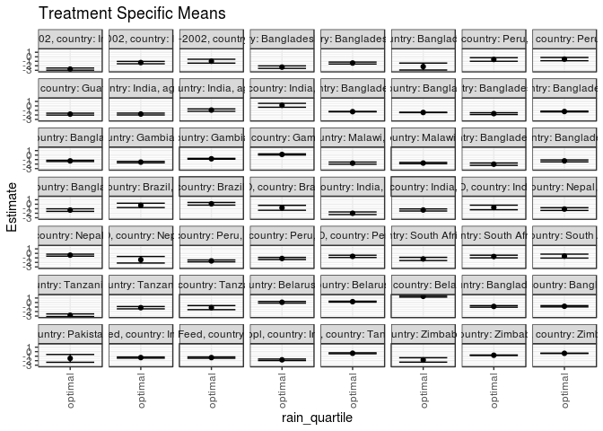

## Results Table

### Parameter: TSM

| studyid | country | agecat | intervention_level | baseline_level | estimate | ci_lower | ci_upper |
| --- | --- | --- | --- | --- | --- | --- | --- |
| CMC-V-BCS-2002 | India | Birth | optimal | observed | -0.9812204 | -1.4155386 | -0.5469022 |
| CMC-V-BCS-2002 | India | 6 months | optimal | observed | -1.2878412 | -1.5536129 | -1.0220696 |
| CMC-V-BCS-2002 | India | 24 months | optimal | observed | -2.7372632 | -2.9776186 | -2.4969077 |
| CMIN | Bangladesh | Birth | optimal | observed | -2.1713313 | -2.9404847 | -1.4021780 |
| CMIN | Bangladesh | 6 months | optimal | observed | -1.3883786 | -1.6081686 | -1.1685885 |
| CMIN | Bangladesh | 24 months | optimal | observed | -2.2947643 | -2.5727930 | -2.0167355 |
| CONTENT | Peru | 6 months | optimal | observed | -0.5179023 | -0.8806737 | -0.1551308 |
| CONTENT | Peru | 24 months | optimal | observed | -0.5964713 | -0.9927549 | -0.2001876 |
| Guatemala BSC | Guatemala | 6 months | optimal | observed | -1.8175642 | -2.0289987 | -1.6061297 |
| IRC | India | Birth | optimal | observed | 0.1424409 | -0.2891676 | 0.5740495 |
| IRC | India | 6 months | optimal | observed | -0.9220705 | -1.1836911 | -0.6604499 |
| IRC | India | 24 months | optimal | observed | -1.7978577 | -2.0043718 | -1.5913437 |
| JiVitA-3 | Bangladesh | Birth | optimal | observed | -1.4499254 | -1.4875228 | -1.4123279 |
| JiVitA-3 | Bangladesh | 6 months | optimal | observed | -1.2693124 | -1.3123336 | -1.2262912 |
| JiVitA-4 | Bangladesh | Birth | optimal | observed | -1.2903169 | -1.4244208 | -1.1562131 |
| JiVitA-4 | Bangladesh | 6 months | optimal | observed | -1.2385113 | -1.3201886 | -1.1568341 |
| JiVitA-4 | Bangladesh | 24 months | optimal | observed | -1.7038069 | -1.9043966 | -1.5032172 |
| Keneba | Gambia | Birth | optimal | observed | 0.1395870 | 0.0190801 | 0.2600939 |
| Keneba | Gambia | 6 months | optimal | observed | -0.8250953 | -0.9158829 | -0.7343077 |
| Keneba | Gambia | 24 months | optimal | observed | -1.5611552 | -1.7218450 | -1.4004655 |
| LCNI-5 | Malawi | 6 months | optimal | observed | -1.7714208 | -1.9158932 | -1.6269485 |
| LCNI-5 | Malawi | 24 months | optimal | observed | -1.7921696 | -2.0285338 | -1.5558055 |
| MAL-ED | Bangladesh | Birth | optimal | observed | -1.3026465 | -1.5835474 | -1.0217456 |
| MAL-ED | Bangladesh | 6 months | optimal | observed | -1.2898130 | -1.5043563 | -1.0752698 |
| MAL-ED | Bangladesh | 24 months | optimal | observed | -2.0227749 | -2.2858786 | -1.7596712 |
| MAL-ED | Brazil | Birth | optimal | observed | -0.7932093 | -1.3419701 | -0.2444486 |
| MAL-ED | Brazil | 6 months | optimal | observed | 0.0959358 | -0.1987859 | 0.3906575 |
| MAL-ED | Brazil | 24 months | optimal | observed | -0.2603678 | -0.7433516 | 0.2226160 |
| MAL-ED | India | Birth | optimal | observed | -0.7201532 | -1.2257430 | -0.2145634 |
| MAL-ED | India | 6 months | optimal | observed | -1.2817170 | -1.5128578 | -1.0505762 |
| MAL-ED | India | 24 months | optimal | observed | -2.0014125 | -2.2950711 | -1.7077539 |
| MAL-ED | Nepal | Birth | optimal | observed | -1.4143808 | -2.1430082 | -0.6857535 |
| MAL-ED | Nepal | 6 months | optimal | observed | -0.3917389 | -0.6130218 | -0.1704560 |
| MAL-ED | Nepal | 24 months | optimal | observed | -1.0761758 | -1.3749352 | -0.7774164 |
| MAL-ED | Peru | Birth | optimal | observed | -0.6615383 | -0.9177849 | -0.4052918 |
| MAL-ED | Peru | 6 months | optimal | observed | -1.1324567 | -1.3732150 | -0.8916985 |
| MAL-ED | Peru | 24 months | optimal | observed | -1.6743144 | -1.8847592 | -1.4638696 |
| MAL-ED | South Africa | Birth | optimal | observed | -0.6089993 | -1.0491554 | -0.1688433 |
| MAL-ED | South Africa | 6 months | optimal | observed | -0.7013379 | -0.9993165 | -0.4033593 |
| MAL-ED | South Africa | 24 months | optimal | observed | -1.2365057 | -1.5929419 | -0.8800696 |
| MAL-ED | Tanzania | Birth | optimal | observed | -1.1332631 | -1.5851992 | -0.6813271 |
| MAL-ED | Tanzania | 6 months | optimal | observed | -1.1493421 | -1.4085300 | -0.8901542 |
| MAL-ED | Tanzania | 24 months | optimal | observed | -2.8206439 | -3.1145800 | -2.5267078 |
| PROBIT | Belarus | Birth | optimal | observed | 1.3747662 | 1.2052538 | 1.5442786 |
| PROBIT | Belarus | 6 months | optimal | observed | 0.1888661 | 0.0808729 | 0.2968593 |
| PROBIT | Belarus | 24 months | optimal | observed | 0.0573202 | -0.1312241 | 0.2458645 |
| PROVIDE | Bangladesh | Birth | optimal | observed | -0.8301474 | -0.9766558 | -0.6836389 |
| PROVIDE | Bangladesh | 6 months | optimal | observed | -0.8677412 | -1.0412703 | -0.6942121 |
| ResPak | Pakistan | 6 months | optimal | observed | -1.4880383 | -2.3520624 | -0.6240143 |
| SAS-CompFeed | India | Birth | optimal | observed | -1.3137866 | -1.4624821 | -1.1650912 |
| SAS-CompFeed | India | 6 months | optimal | observed | -1.3085853 | -1.4410899 | -1.1760808 |
| SAS-FoodSuppl | India | 6 months | optimal | observed | -1.8062575 | -1.9754360 | -1.6370790 |
| TanzaniaChild2 | Tanzania | 6 months | optimal | observed | -0.3499844 | -0.4542793 | -0.2456894 |
| ZVITAMBO | Zimbabwe | Birth | optimal | observed | -0.3650153 | -0.4031278 | -0.3269028 |
| ZVITAMBO | Zimbabwe | 6 months | optimal | observed | -0.7952009 | -0.8462123 | -0.7441895 |
| ZVITAMBO | Zimbabwe | 24 months | optimal | observed | -1.8361470 | -2.3269840 | -1.3453100 |

### Parameter: E(Y)

| studyid | country | agecat | intervention_level | baseline_level | estimate | ci_lower | ci_upper |
| --- | --- | --- | --- | --- | --- | --- | --- |
| CMC-V-BCS-2002 | India | Birth | observed | observed | -0.9611957 | -1.1776967 | -0.7446946 |
| CMC-V-BCS-2002 | India | 6 months | observed | observed | -1.4234508 | -1.5645974 | -1.2823042 |
| CMC-V-BCS-2002 | India | 24 months | observed | observed | -2.6927477 | -2.7980658 | -2.5874297 |
| CMIN | Bangladesh | Birth | observed | observed | -1.8811538 | -2.5124807 | -1.2498270 |
| CMIN | Bangladesh | 6 months | observed | observed | -1.7844376 | -1.9222926 | -1.6465825 |
| CMIN | Bangladesh | 24 months | observed | observed | -2.5563616 | -2.6853113 | -2.4274119 |
| CONTENT | Peru | 6 months | observed | observed | -0.3139217 | -0.4868486 | -0.1409948 |
| CONTENT | Peru | 24 months | observed | observed | -0.6962195 | -0.8674103 | -0.5250287 |
| Guatemala BSC | Guatemala | 6 months | observed | observed | -1.5619008 | -1.6727702 | -1.4510313 |
| IRC | India | Birth | observed | observed | -0.3080412 | -0.4687931 | -0.1472894 |
| IRC | India | 6 months | observed | observed | -1.2344062 | -1.3658524 | -1.1029600 |
| IRC | India | 24 months | observed | observed | -1.8787176 | -1.9805661 | -1.7768691 |
| JiVitA-3 | Bangladesh | Birth | observed | observed | -1.5894148 | -1.6086362 | -1.5701935 |
| JiVitA-3 | Bangladesh | 6 months | observed | observed | -1.3130932 | -1.3362359 | -1.2899505 |
| JiVitA-4 | Bangladesh | Birth | observed | observed | -1.5232908 | -1.5723277 | -1.4742539 |
| JiVitA-4 | Bangladesh | 6 months | observed | observed | -1.3447940 | -1.3820261 | -1.3075620 |
| JiVitA-4 | Bangladesh | 24 months | observed | observed | -1.9327943 | -1.9977741 | -1.8678145 |
| Keneba | Gambia | Birth | observed | observed | 0.0308036 | -0.0328378 | 0.0944451 |
| Keneba | Gambia | 6 months | observed | observed | -0.9036375 | -0.9508087 | -0.8564663 |
| Keneba | Gambia | 24 months | observed | observed | -1.6554946 | -1.7360989 | -1.5748903 |
| LCNI-5 | Malawi | 6 months | observed | observed | -1.6601907 | -1.7297701 | -1.5906113 |
| LCNI-5 | Malawi | 24 months | observed | observed | -2.0459112 | -2.1718307 | -1.9199918 |
| MAL-ED | Bangladesh | Birth | observed | observed | -1.1180952 | -1.2525408 | -0.9836496 |
| MAL-ED | Bangladesh | 6 months | observed | observed | -1.2049931 | -1.3222136 | -1.0877726 |
| MAL-ED | Bangladesh | 24 months | observed | observed | -2.0203209 | -2.1567304 | -1.8839113 |
| MAL-ED | Brazil | Birth | observed | observed | -0.6760000 | -0.9521457 | -0.3998543 |
| MAL-ED | Brazil | 6 months | observed | observed | 0.0475758 | -0.0963508 | 0.1915023 |
| MAL-ED | Brazil | 24 months | observed | observed | -0.0663473 | -0.2413659 | 0.1086713 |
| MAL-ED | India | Birth | observed | observed | -1.2036170 | -1.4976814 | -0.9095527 |
| MAL-ED | India | 6 months | observed | observed | -1.2115254 | -1.3298727 | -1.0931782 |
| MAL-ED | India | 24 months | observed | observed | -1.9337871 | -2.0691373 | -1.7984370 |
| MAL-ED | Nepal | Birth | observed | observed | -0.8533333 | -1.2104864 | -0.4961803 |
| MAL-ED | Nepal | 6 months | observed | observed | -0.5615819 | -0.6741832 | -0.4489807 |
| MAL-ED | Nepal | 24 months | observed | observed | -1.3339250 | -1.4668700 | -1.2009800 |
| MAL-ED | Peru | Birth | observed | observed | -0.8827897 | -1.0001058 | -0.7654736 |
| MAL-ED | Peru | 6 months | observed | observed | -1.3236661 | -1.4316775 | -1.2156546 |
| MAL-ED | Peru | 24 months | observed | observed | -1.8184925 | -1.9407024 | -1.6962825 |
| MAL-ED | South Africa | Birth | observed | observed | -0.6317073 | -0.8249555 | -0.4384591 |
| MAL-ED | South Africa | 6 months | observed | observed | -1.0633202 | -1.1909180 | -0.9357224 |
| MAL-ED | South Africa | 24 months | observed | observed | -1.7086453 | -1.8487775 | -1.5685131 |
| MAL-ED | Tanzania | Birth | observed | observed | -1.1556000 | -1.3655361 | -0.9456639 |
| MAL-ED | Tanzania | 6 months | observed | observed | -1.3687449 | -1.4907629 | -1.2467270 |
| MAL-ED | Tanzania | 24 months | observed | observed | -2.6979508 | -2.8450645 | -2.5508372 |
| PROBIT | Belarus | Birth | observed | observed | 1.3269446 | 1.1683850 | 1.4855041 |
| PROBIT | Belarus | 6 months | observed | observed | 0.1068536 | 0.0120998 | 0.2016074 |
| PROBIT | Belarus | 24 months | observed | observed | -0.2282149 | -0.4620519 | 0.0056221 |
| PROVIDE | Bangladesh | Birth | observed | observed | -0.8851020 | -0.9601332 | -0.8100709 |
| PROVIDE | Bangladesh | 6 months | observed | observed | -1.0916915 | -1.1661176 | -1.0172654 |
| ResPak | Pakistan | 6 months | observed | observed | -1.4314086 | -1.6374838 | -1.2253335 |
| SAS-CompFeed | India | Birth | observed | observed | -1.4314217 | -1.5099245 | -1.3529189 |
| SAS-CompFeed | India | 6 months | observed | observed | -1.4018563 | -1.4810585 | -1.3226541 |
| SAS-FoodSuppl | India | 6 months | observed | observed | -1.8986842 | -2.0118892 | -1.7854792 |
| TanzaniaChild2 | Tanzania | 6 months | observed | observed | -0.5434389 | -0.5924056 | -0.4944722 |
| ZVITAMBO | Zimbabwe | Birth | observed | observed | -0.5002724 | -0.5208163 | -0.4797285 |
| ZVITAMBO | Zimbabwe | 6 months | observed | observed | -0.8679450 | -0.8935071 | -0.8423828 |
| ZVITAMBO | Zimbabwe | 24 months | observed | observed | -1.8369146 | -1.9746779 | -1.6991513 |

### Parameter: PAR

| studyid | country | agecat | intervention_level | baseline_level | estimate | ci_lower | ci_upper |
| --- | --- | --- | --- | --- | --- | --- | --- |
| CMC-V-BCS-2002 | India | Birth | optimal | observed | 0.0200247 | -0.3340003 | 0.3740497 |
| CMC-V-BCS-2002 | India | 6 months | optimal | observed | -0.1356095 | -0.3674814 | 0.0962623 |
| CMC-V-BCS-2002 | India | 24 months | optimal | observed | 0.0445154 | -0.1698458 | 0.2588766 |
| CMIN | Bangladesh | Birth | optimal | observed | 0.2901775 | -0.5855162 | 1.1658712 |
| CMIN | Bangladesh | 6 months | optimal | observed | -0.3960590 | -0.6046719 | -0.1874461 |
| CMIN | Bangladesh | 24 months | optimal | observed | -0.2615974 | -0.5040203 | -0.0191744 |
| CONTENT | Peru | 6 months | optimal | observed | 0.2039806 | -0.1402382 | 0.5481994 |
| CONTENT | Peru | 24 months | optimal | observed | -0.0997482 | -0.4511696 | 0.2516731 |
| Guatemala BSC | Guatemala | 6 months | optimal | observed | 0.2556634 | 0.0696137 | 0.4417131 |
| IRC | India | Birth | optimal | observed | -0.4504822 | -0.8234279 | -0.0775364 |
| IRC | India | 6 months | optimal | observed | -0.3123357 | -0.5272834 | -0.0973881 |
| IRC | India | 24 months | optimal | observed | -0.0808599 | -0.2504848 | 0.0887651 |
| JiVitA-3 | Bangladesh | Birth | optimal | observed | -0.1394895 | -0.1723206 | -0.1066584 |
| JiVitA-3 | Bangladesh | 6 months | optimal | observed | -0.0437808 | -0.0786000 | -0.0089617 |
| JiVitA-4 | Bangladesh | Birth | optimal | observed | -0.2329739 | -0.3651075 | -0.1008403 |
| JiVitA-4 | Bangladesh | 6 months | optimal | observed | -0.1062827 | -0.1839189 | -0.0286465 |
| JiVitA-4 | Bangladesh | 24 months | optimal | observed | -0.2289874 | -0.4178556 | -0.0401193 |
| Keneba | Gambia | Birth | optimal | observed | -0.1087834 | -0.2159021 | -0.0016648 |
| Keneba | Gambia | 6 months | optimal | observed | -0.0785422 | -0.1563808 | -0.0007036 |
| Keneba | Gambia | 24 months | optimal | observed | -0.0943393 | -0.2336155 | 0.0449368 |
| LCNI-5 | Malawi | 6 months | optimal | observed | 0.1112301 | -0.0138222 | 0.2362824 |
| LCNI-5 | Malawi | 24 months | optimal | observed | -0.2537416 | -0.4682311 | -0.0392520 |
| MAL-ED | Bangladesh | Birth | optimal | observed | 0.1845513 | -0.0586776 | 0.4277801 |
| MAL-ED | Bangladesh | 6 months | optimal | observed | 0.0848199 | -0.1012170 | 0.2708569 |
| MAL-ED | Bangladesh | 24 months | optimal | observed | 0.0024540 | -0.2254033 | 0.2303114 |
| MAL-ED | Brazil | Birth | optimal | observed | 0.1172093 | -0.3983034 | 0.6327220 |
| MAL-ED | Brazil | 6 months | optimal | observed | -0.0483600 | -0.2905414 | 0.1938214 |
| MAL-ED | Brazil | 24 months | optimal | observed | 0.1940205 | -0.2223491 | 0.6103901 |
| MAL-ED | India | Birth | optimal | observed | -0.4834638 | -0.9835812 | 0.0166535 |
| MAL-ED | India | 6 months | optimal | observed | 0.0701916 | -0.1420202 | 0.2824034 |
| MAL-ED | India | 24 months | optimal | observed | 0.0676254 | -0.1837670 | 0.3190178 |
| MAL-ED | Nepal | Birth | optimal | observed | 0.5610475 | -0.1349854 | 1.2570804 |
| MAL-ED | Nepal | 6 months | optimal | observed | -0.1698431 | -0.3632288 | 0.0235427 |
| MAL-ED | Nepal | 24 months | optimal | observed | -0.2577492 | -0.5317647 | 0.0162663 |
| MAL-ED | Peru | Birth | optimal | observed | -0.2212514 | -0.4500943 | 0.0075916 |
| MAL-ED | Peru | 6 months | optimal | observed | -0.1912093 | -0.4032810 | 0.0208623 |
| MAL-ED | Peru | 24 months | optimal | observed | -0.1441781 | -0.3430483 | 0.0546922 |
| MAL-ED | South Africa | Birth | optimal | observed | -0.0227080 | -0.3677747 | 0.3223587 |
| MAL-ED | South Africa | 6 months | optimal | observed | -0.3619823 | -0.6362010 | -0.0877636 |
| MAL-ED | South Africa | 24 months | optimal | observed | -0.4721396 | -0.8028153 | -0.1414639 |
| MAL-ED | Tanzania | Birth | optimal | observed | -0.0223369 | -0.3935071 | 0.3488333 |
| MAL-ED | Tanzania | 6 months | optimal | observed | -0.2194028 | -0.4516894 | 0.0128838 |
| MAL-ED | Tanzania | 24 months | optimal | observed | 0.1226931 | -0.1285640 | 0.3739502 |
| PROBIT | Belarus | Birth | optimal | observed | -0.0478216 | -0.0921015 | -0.0035417 |
| PROBIT | Belarus | 6 months | optimal | observed | -0.0820125 | -0.1364169 | -0.0276080 |
| PROBIT | Belarus | 24 months | optimal | observed | -0.2855351 | -0.5775511 | 0.0064809 |
| PROVIDE | Bangladesh | Birth | optimal | observed | -0.0549547 | -0.1809057 | 0.0709963 |
| PROVIDE | Bangladesh | 6 months | optimal | observed | -0.2239503 | -0.3777325 | -0.0701680 |
| ResPak | Pakistan | 6 months | optimal | observed | 0.0566297 | -0.8047490 | 0.9180084 |
| SAS-CompFeed | India | Birth | optimal | observed | -0.1176351 | -0.2284260 | -0.0068443 |
| SAS-CompFeed | India | 6 months | optimal | observed | -0.0932710 | -0.2112977 | 0.0247558 |
| SAS-FoodSuppl | India | 6 months | optimal | observed | -0.0924267 | -0.2240698 | 0.0392164 |
| TanzaniaChild2 | Tanzania | 6 months | optimal | observed | -0.1934545 | -0.2815142 | -0.1053948 |
| ZVITAMBO | Zimbabwe | Birth | optimal | observed | -0.1352571 | -0.1683242 | -0.1021900 |
| ZVITAMBO | Zimbabwe | 6 months | optimal | observed | -0.0727441 | -0.1163853 | -0.0291028 |
| ZVITAMBO | Zimbabwe | 24 months | optimal | observed | -0.0007676 | -0.4532835 | 0.4517483 |